# Advanced Graphics

#### 1.2.2.4 Bivariate quantile-quantile plots

If you would like to generate quantile-quantile plots for comparing two distributions, you can use the function `qq`.

- Compare two distributions of “Bass 2” and “Tenor 1”.

```r
# library(lattice)
head(singer)
```

| height | voice.part |
| --- | --- |
| 64 | Soprano 1 |
| 62 | Soprano 1 |
| 66 | Soprano 1 |
| 65 | Soprano 1 |
| 60 | Soprano 1 |
| 61 | Soprano 1 |

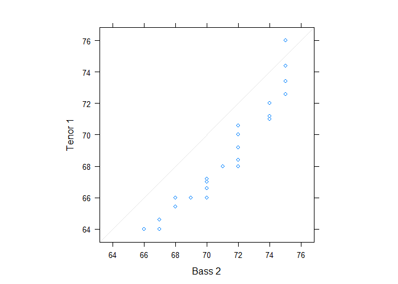

```r
# Figure 30
qq(voice.part ~ height,
   data   = singer,
   aspect = 1,
   subset = (voice.part == "Bass 2" | voice.part == "Tenor 1")
   )
```

`aspect = 1` means the length of the x-axis is equal to that of the y-axis. As we can see, there’s a little difference between two distributions because the plotted points don’t form a straight diagonal line.

### 1.2.3 Trivariate Trellis Plots

If you would like to plot three-dimensional data with Trellis graphics, there are several functions available.

#### 1.2.3.1 Level plots

`levelplot` function can plot three-dimensional data in flat grids, with colors showing different values for the third dimension. As an example of level plots, we also look at the San Francisco home sales data set.

- Show the number of home sales in different parts of the city. You can use that coordinate data in the San Francisco home sales data set.

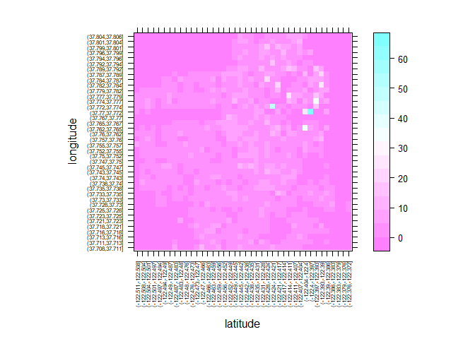

```r
# Figure 31
attach(sanfrancisco.home.sales)
levelplot(table(cut(longitude, breaks = 40), cut(latitude, breaks = 40)),
          scales = list(y = list(cex = .5), x = list(rot = 90, cex = .5)),
          xlab   = "latitude",
          ylab   = "longitude"
          )
```

The `table` and `cut` functions are to break the **longitude** and **latitude** data into bins and count the number of homes within each bin. `xlab` and `ylab` function is a character or expression (or a “grob”) giving label(s) for the x-axis and y-axis.

If we were interested in looking at the average sales price by area, we could use a similar strategy. Instead of table, you can use the tapply function to aggregate observations.

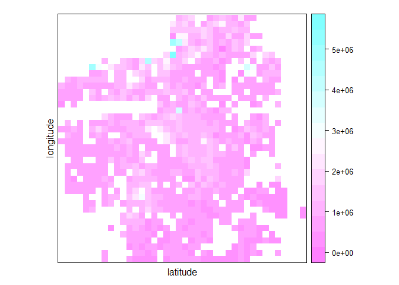

```r
# Figure 32
levelplot(tapply(price,
                 INDEX = list(cut(longitude, breaks = 40), cut(latitude, breaks = 40)),
                 FUN   = mean),
          scales = list(draw = FALSE),
          xlab = "latitude",
          ylab = "longitude"
          )
```

`scales` is generally a list determining how the x- and y-axes (tick marks and labels) are drawn. `draw` is a logical flag, determines whether to draw the axis (i.e., tick marks and labels) at all.

Of course, you can use conditioning values with level plots.

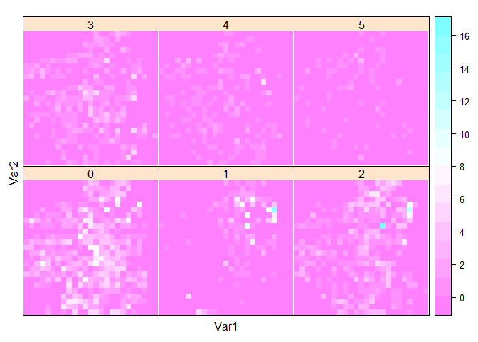

```r
# Figure 33
bedrooms.capped <- ifelse(bedrooms<5, bedrooms, 5)
levelplot(table(cut(longitude, breaks = 25),cut(latitude, breaks = 25), bedrooms.capped),
          scales = list(draw = FALSE)
          )
```

#### 1.2.3.2 Contour plots

`contourplot` function is to to show contour plots with lattice (which resemble topographic maps). We can use `?contourplot` to see more details.

- A simple example:

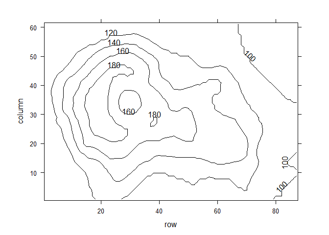

```r
# Figure 34
contourplot(volcano)
```

#### 1.2.3.3 Cloud plots

`cloud` function is to plot points in three dimensions (technically, projections into two dimensions of the points in three dimensions). You can use `?cloud` to see more details. The data set **volcano** is package datasets.

- A simple example:

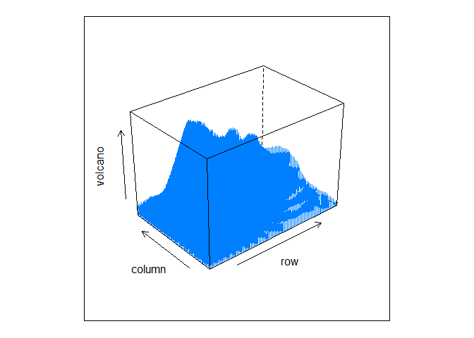

```r
# Figure 35
cloud(volcano, zlab = list("volcano", rot = 90))
```

#### 1.2.3.4 Wire-frame plots

If you would like to show a three-dimensional surface, you could use the function `wireframe`.

- A simple example:

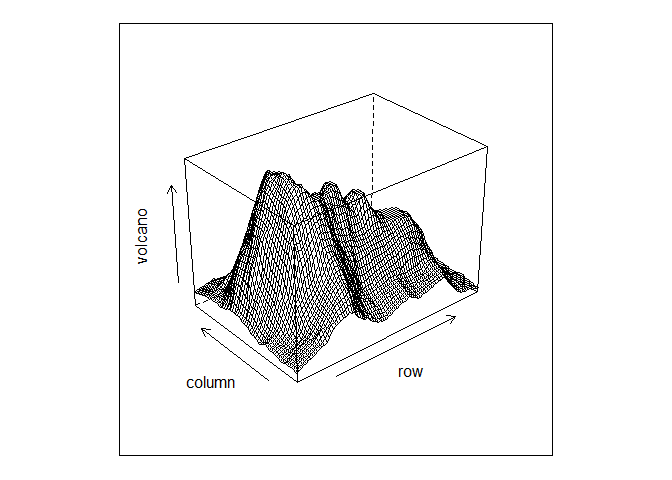

```r
# Figure 36
wireframe(volcano, zlab = list("volcano", rot = 90))
```

### 1.2.4 Other Plots

If you have fitted a model to a data set, the rfs function can help you visualize how well the model fits the data. The rfs function plots residual and fit-spread (RFS) plots.

```r
# library(nutshell)
data(team.batting.00to08)
head(team.batting.00to08)
```

| teamID | yearID | runs | singles | doubles | triples | homeruns | walks | stolenbases | caughtstealing | hitbypitch | sacrificeflies | atbats |
| --- | --- | --- | --- | --- | --- | --- | --- | --- | --- | --- | --- | --- |
| ANA | 2000 | 864 | 995 | 309 | 34 | 236 | 608 | 93 | 52 | 47 | 43 | 5628 |
| BAL | 2000 | 794 | 992 | 310 | 22 | 184 | 558 | 126 | 65 | 49 | 54 | 5549 |
| BOS | 2000 | 792 | 988 | 316 | 32 | 167 | 611 | 43 | 30 | 42 | 48 | 5630 |
| CHA | 2000 | 978 | 1041 | 325 | 33 | 216 | 591 | 119 | 42 | 53 | 61 | 5646 |
| CLE | 2000 | 950 | 1078 | 310 | 30 | 221 | 685 | 113 | 34 | 51 | 52 | 5683 |
| DET | 2000 | 823 | 1028 | 307 | 41 | 177 | 562 | 83 | 38 | 43 | 49 | 5644 |

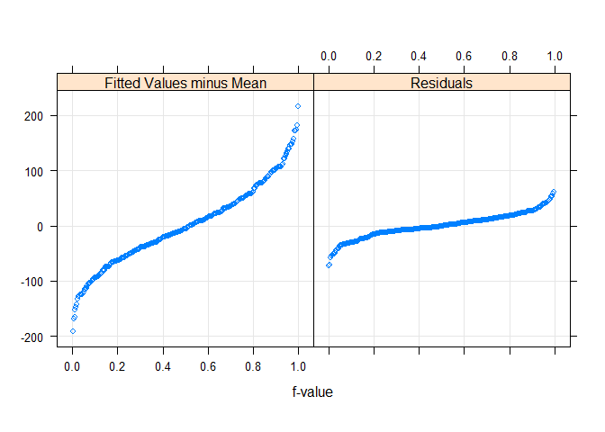

```r
# Figure 37
attach(team.batting.00to08)
rfs(lm(formula = runs~singles+doubles+triples+homeruns+walks+
                      hitbypitch+sacrificeflies+stolenbases+caughtstealing,
       data = team.batting.00to08),
    aspect = 1
    )
```

Notice that the two curves are S shaped. The residual plot is a quantile-quantile plot of the residuals. Because the default distribution choice for `rfs` is a uniform distribution, we need to modify certain arguments.

- Show the fitted results and determine if the residuals fit the normal distribution:

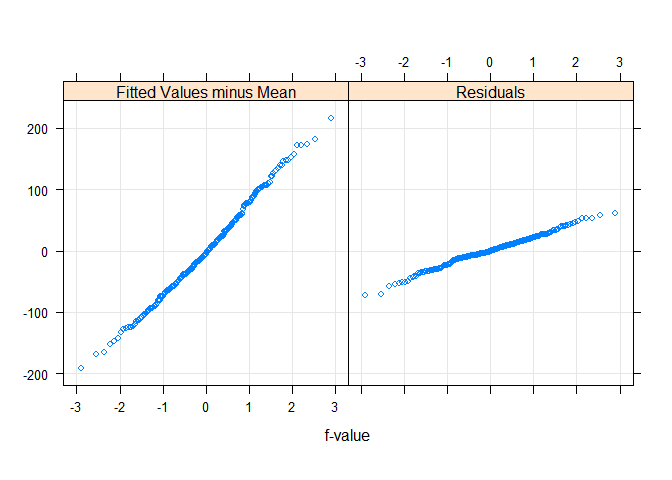

```r
# Figure 38
rfs(lm(formula = runs~singles+doubles+triples+homeruns+walks+
                      hitbypitch+sacrificeflies+stolenbases+caughtstealing,
       data = team.batting.00to08),
    aspect = 1,
    distribution = qnorm
    )
```

Notice that the plots are roughly linear. We expect a normally distributed error function for a linear regression model, and this is a good thing.

### 1.2.5 Customizing Lattice Graphics

Most lattice functions share common arguments; the same argument has a similar effect in multiple functions. Let’s describe what each of those arguments does and explain how to fine-tune the output of lattice functions.

#### 1.2.5.1 Common Arguments to Lattice Functions

Lattice functions share many common arguments. Instead of explaining what each function does separately we’ll explain them in a single table.

| Argument | Description |
| --- | --- |
| x | The object to plot. May be a formula, array, numeric vector, or table. |
| data | When x is a formula, data is a data frame in which the function is evaluated. |
| allow.multiple | Specifies how to interpret formulas of the form y1 + y2 ~ X \| Z (where X is a function of multiple variables and Z may also be a function of multiple variables) |
| outer | Specifies whether to superimpose plots or not when allow.multiple=TRUE and multiple dependent variables are specified. |
| box.ratio | For plots that show data in rectangles (bwplot, barchart, and stripplot), a numeric value that specifies the ratio of the width of the rectangles to the inner rectangle space. |
| horizontal | For plots that can be laid out vertically or horizontally (bwplot, dotplot, barchart and stripplot), a logical value that specifies the direction to plot. |
| panel | The panel function used to actually draw the plots. |
| aspect | Specifies the aspect ratio to use for different panels. |
| groups | Specifies a variable (or expression of variables) describing groups of data to pass to the panel function. |
| auto.key | A logical value specifying whether to automatically draw a key showing the names of groups corresponding to different colors or symbols. |
| prepanel | A function that takes the same arguments as panel and returns a list containing values xlim, ylim, dx, and dy (and, less frequently, xat and yat). |
| strip | A logical value specifying whether strips (that label panels) should be drawn. |
| xlab | A character value specifying the label for the x-axis. |
| ylab | A character value specifying the label for the y-axis. |
| scales | A list that specifies how the x- and y-axes should be drawn. |
| subscripts | A logical value specifying whether a vector named subscripts should be passed to the panel function. |
| subset | Specifies the subset of values from data to plot. |
| xlim | Specifies the minimum and maximum values for the x-axis. |
| ylim | Specifies the minimum and maximum values for the y-axis. |
| drop.unused.levels | A logical value (or a list outlining what to do for different components of x) specifying whether to drop unused levels of factors. |
| default.scales | A list giving the default value of scales. |
| lattice.options | A list of plotting parameters, similar to par values for standard R graphics. |

If you would like to get more information about augments, see the help files.

#### 1.2.5.2 Controlling How Axes Are Drawn

You can control how axes are drawn in the lattice package by named values in the argument `scales`. Here is a table of the available arguments.

| Argument | Description |
| --- | --- |
| rot | Angle to rotate axis labels. Can specify a vector of length 2 to separately control left/bottom and right/top. |
| cex | A numeric value that controls the size of axis labels (âcharacter expansionâ factor). Can specify a vector of length 2 to separately control left/bottom and right/top. |
| limits | Limits for each axis; equivalent to xlim and ylim. |
| axs | Use axs=“r” to pad date values on each side, axs=“i” to use exact values. |
| at | A numeric vector describing where to plot tick marks (in native coordinates) or a list describing where to plot tick marks for each panel. |
| labels | Labels to accompany at, specified as a vector (or list of vectors). |
| tck | A numeric value specifying the length of the tick marks. |

For more details on other arguments, you can see the page 310 of the book *R IN A NUTSHELL*.

#### 1.2.5.3 Parameters

In the graphics package, we use `par` function to set or query default parameters.

- Check the value of the parameter cex:

```r
par("cex")
```

```
## [1] 1
```

That is a similar mechanism for lattice graphics. To check the value of a setting, use the function `trellis.par.get`. To change a setting, use the function `trellis.par.set`

- Check the values of the `axis.text` parameter, which controls the look of text printed on axes:

```r
trellis.par.get("axis.text")
```

```
## $alpha
## [1] 1
##
## $cex
## [1] 0.8
##
## $col
## [1] "#000000"
##
## $font
## [1] 1
##
## $lineheight
## [1] 1
```

- Change the parameter `axis.text$cex` to 0.5

```r
trellis.par.set(list(axis.text = list(cex = 0.5)))
```

- Show a list of all settings:

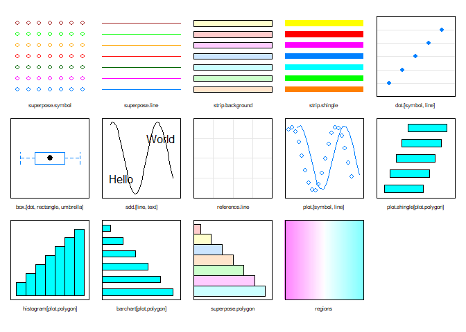

```r
show.settings()
```

We can also use `trellis.par.get()`.

```r
names(trellis.par.get())
```

```
##  [1] "grid.pars"         "fontsize"          "background"
##  [4] "panel.background"  "clip"              "add.line"
##  [7] "add.text"          "plot.polygon"      "box.dot"
## [10] "box.rectangle"     "box.umbrella"      "dot.line"
## [13] "dot.symbol"        "plot.line"         "plot.symbol"
## [16] "reference.line"    "strip.background"  "strip.shingle"
## [19] "strip.border"      "superpose.line"    "superpose.symbol"
## [22] "superpose.polygon" "regions"           "shade.colors"
## [25] "axis.line"         "axis.text"         "axis.components"
## [28] "layout.heights"    "layout.widths"     "box.3d"
## [31] "par.xlab.text"     "par.ylab.text"     "par.zlab.text"
## [34] "par.main.text"     "par.sub.text"
```

There are 35 highlevel groups of parameters describing how different components are drawn. If you want to know details of what each of these groups of parameters control, please refer to page 313 of the book *“R in a nutshell”*.

#### 1.2.5.4 `plot.trellis`

As we noted above, lattice functions do not plot results; they return lattice objects. To plot a lattice object, you need to call `print.trellis()` or `plot.trellis()` on the lattice object. It’s possible to control how lattice objects are printed through changing arguments of them.

- Get the list of arguments for `plot.trellis()`

```
?plot.trellis
```

#### 1.2.5.5 strip.default

To change the way strips are drawn, you can specify your own strip function as an argument to a lattice function. The simplest way to modify the appearance of the strips is by using the function `strip.custom`. This function accepts the same arguments as `strip.default` and returns a new function that can be specified as an argument to a lattice function. **We have used this function when ploting Figure 25**.

```
?strip.default
```

### 1.2.6 Low-Level Functions

The lattice package includes a variety of different panel functions that you can use to customize your charts. For example, you can use these functions to add lines, text, and other graphical elements to lattice graphics.

| Function(s) | Description |
| --- | --- |
| llines, panel.line | Plots lines |
| lpoints, panel.points | Plots points |
| ltext, panel.text | Plots text |
| panel.axis | Plots axes |
| panel.abline | Adds a line to the chart area of a panel. |
| panel.curve | Adds a curve (defined by a mathematical expression) to the chart area of a panel. |
| panel.mathdensity | Plots a probability distribution given by a distribution function. |
| panel.lmline | Plots a line fitted to the underlying data by a linear regression. |

For more details on other functions, you can see the corresponding help files and page 318-319 of the book *R IN A NUTSHELL*.

# 2 ggplot2

## 2.1 An Overview of ggplot2 Package

**ggplot2** is an R package for producing statistical, or data, graphics, but it is unlike most other graphics packages because it has a deep underlying grammar. This layered grammar, based on **the Grammar of Graphics** (Wilkinson 2005), focuses on the primacy of layers and adapting it for embedding within R. In brief, the grammar tells us that a statistical graphic is a mapping from data to aesthetic attributes (colour, shape, size) of geometric objects (points, lines, bars). This is made up of a set of independent components which makes ggplot2 very powerful because you are not limited to a set of pre-specified graphics, but you can create new graphics that are precisely tailored for your problem.

This package is not part of a standard R installation, so it must first be installed, then it can be loaded into R as follows.

```r
library(ggplot2)
```

In `ggplot2`, all plots are composed of:

- **Data**
- **Layers** made up of geometric elements (**geom**), including points, lines and polygons, and statistical transformation (**stat**), such as histogram or a 2d relationship with a linear model.
- Scales (**scale**) map values in the data space to values in an aesthetic space, whether it be colour, or size, or shape.
- A coordinate system (**coord**) describes how data coordinates are mapped to the plane of the graphic.
- A faceting specification (**facet**) describes how to break up the data into subsets and how to display those subsets as small multiples.
- A **theme** which controls the finer points of display, like the font size and background colour.

Data sets in ggplot2 package:

| Dataset | Description |
| --- | --- |
| diamonds | Prices of 50,000 round cut diamonds |
| economics | US economic time series |
| economics_long | US economic time series |
| faithfuld | 2d density estimate of Old Faithful data |
| luv_colours | ‘colors()’ in Luv space |
| midwest | Midwest demographics |
| mpg | Fuel economy data from 1999 and 2008 for 38 popular models of car |
| msleep | An updated and expanded version of the mammals sleep dataset |
| presidential | Terms of 11 presidents from Eisenhower to Obama |
| seals | Vector field of seal movements |
| txhousing | Housing sales in TX |

In this section, we’ll mostly use one data set that’s bundled with ggplot2: **mpg**. It includes information about the fuel economy of popular car models in 1999 and 2008, collected by the US Environmental Protection Agency.

```r
head(mpg)
```

| manufacturer | model | displ | year | cyl | trans | drv | cty | hwy | fl | class |
| --- | --- | --- | --- | --- | --- | --- | --- | --- | --- | --- |
| audi | a4 | 1.8 | 1999 | 4 | auto(l5) | f | 18 | 29 | p | compact |
| audi | a4 | 1.8 | 1999 | 4 | manual(m5) | f | 21 | 29 | p | compact |
| audi | a4 | 2.0 | 2008 | 4 | manual(m6) | f | 20 | 31 | p | compact |
| audi | a4 | 2.0 | 2008 | 4 | auto(av) | f | 21 | 30 | p | compact |
| audi | a4 | 2.8 | 1999 | 6 | auto(l5) | f | 16 | 26 | p | compact |
| audi | a4 | 2.8 | 1999 | 6 | manual(m5) | f | 18 | 26 | p | compact |

| Argument | Description |
| --- | --- |
| cty and hwy | record miles per gallon (mpg) for city and highway driving. |
| displ | the engine displacement in litres. |
| drv | the drivetrain: front wheel (f), rear wheel (r) or four wheel (4). |
| model | the model of car. |
| class | a categorical variable describing the âtypeâ of car: two seater, SUV, compact, etc. |

## 2.2 Getting Started with ggplot2

### 2.2.1 Key Components

Every ggplot2 plot has three key components:

1. **data**
2. A set of **aesthetic mappings** between variables in the data and visual properties, and
3. At least one layer which describes how to render each observation. Layers are usually created with a **geom** function.
- Use a scatterplot to show the relationship between engine size and fuel economy:

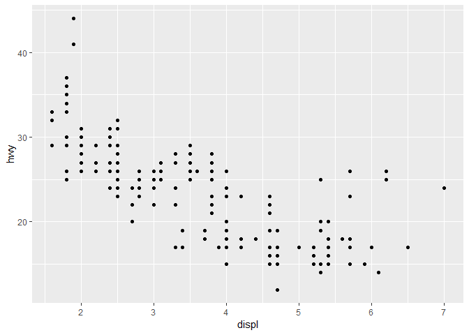

```r
# Figure 1
ggplot(mpg, aes(x = displ, y = hwy)) +
  geom_point()
```

This produces a scatterplot defined by:

1. Data: mpg.
2. Aesthetic mapping: engine size mapped to x position, fuel economy to y position.
3. Layer: points.

Pay attention to the structure of this function call: data and aesthetic mappings are supplied in `ggplot()`, then layers are added on with **+**.

### 2.2.2 Aesthetic Attributes

To add additional variables to a plot, we can use other aesthetics like colour, shape, and size. These work in the same way as the x and y aesthetics, and are added into the call to `aes()`:

- Rerun the above code, underlining their classes.

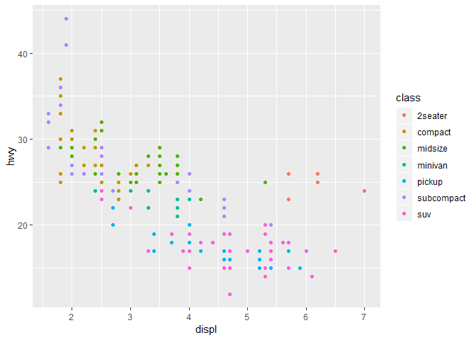

```r
# Figure 2
ggplot(mpg, aes(displ, hwy, colour = class)) +
  geom_point()
```

This gives each point a unique colour corresponding to its class. The legend allows us to read data values from the colour. You can also use `aes(displ, hwy, shape = class)` and `aes(displ, hwy, size = class)` to distinguish classes.

- Change the colour, shape and size of points

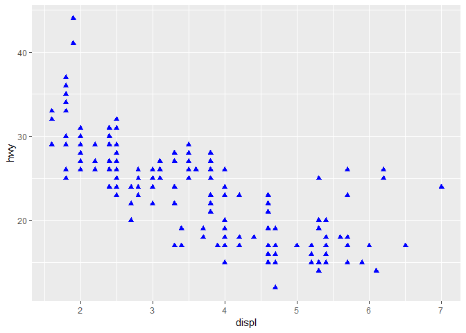

```r
# Figure 3
ggplot(mpg, aes(displ, hwy)) +
  geom_point(colour = "blue", shape = 17, size = 2)
```

### 2.2.3 Facetting

Another technique for displaying additional categorical variables on a plot is facetting. Facetting creates tables of graphics by splitting the data into subsets and displaying the same graph for each subset.

There are two types of facetting: grid and wrapped. Wrapped is the most useful, so take it as an example.

- Split the data into subsets by class and display the same graph for each subset:

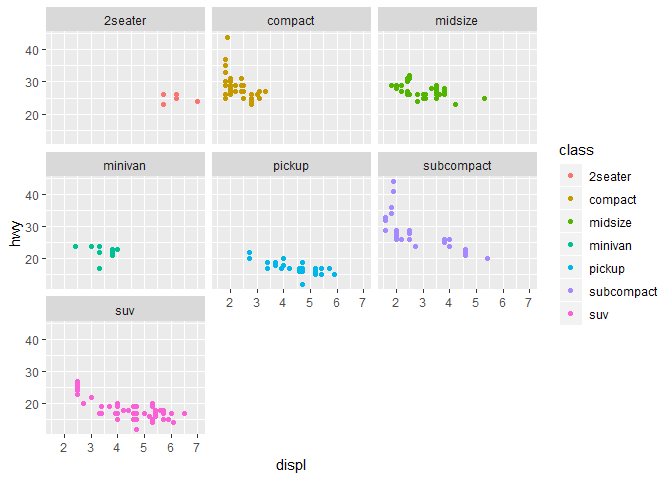

```r
# Figure 4
ggplot(mpg, aes(displ, hwy, colour = class)) +
  geom_point() +
  facet_wrap(~class)
```

### 2.2.4 Plot Geoms

Substituting `geom_point()` for a different `geom` function, you’d get a different type of plot. There is some of the other important geoms provided in ggplot2. This isn’t an exhaustive list, but should cover the most commonly used plot types.

| Geoms | Description | Aesthetics |
| --- | --- | --- |
| geom_point() | Data symbols | x, y, shape, fill, alpha, stroke |
| geom_line() | Line (ordered on x) | x, y, alpha, linetype |
| geom_path() | Line (original order) | x, y, alpha, linetype |
| geom_text() | Text labels | x, y, label, angle, hjust, vjust |
| geom_rect() | Rectangles | xmin, xmax, ymin, ymax, fill, linetype |
| geom_polygon() | Polygons | x, y, fill, linetype |
| geom_segment() | Line segments | x, y, xend, yend, linetype |
| geom_bar() | Bars | x, y, alpha, fill, linetype |
| geom_histogram() | Histogram | x, y, alpha, fill, linetype |
| geom_boxplot() | Boxplots | x, lower, upper, middle, ymin, ymax, alpha, fill, weight, shape |
| geom_density() | Density | x, y, fill, linetype, weight |
| geom_contour() | Contour lines | x, y, alpha, fill, linetype, weight |
| geom_smooth() | Smoothed line | x, y, alpha, fill, linetype, weight |
| ALL |  | color, size, group |

Here’s some common aesthetics:

| Aesthetics | Explanation |
| --- | --- |
| shape | takes four types of values: an integer in [0, 25], a single character, a “.”, an NA |
| fill | fills different colours according to its value (do well in histogram and boxplot) |
| alpha | makes the points transparent (very useful for larger datasets with more overplotting) |
| stroke | modifies the width of the border |
| linetype | solid (default), dotted and dashed |
| label | modifies the xlab and ylab |
| angle | control the display direction of the axis text |
| hjust | controls horizontal justification, defined between 0 and 1 |
| vjust | controls vertical justification, defined between 0 and 1 |

#### 2.2.4.1 Adding a Smoother to a Plot

- Add a smoothed line to the scatterplot:

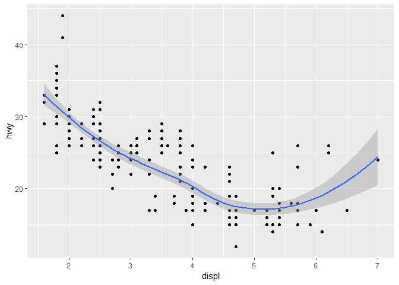

```r
# Figure 5
ggplot(mpg, aes(displ, hwy)) +
  geom_point() +
  geom_smooth()
```

This overlays the `scatterplot` with a smooth curve, including an assessment of uncertainty in the form of point-wise confidence intervals shown in grey. If you’re not interested in the confidence interval, turn it off with `geom_smooth(se = FALSE)`.

An important argument to `geom_smooth()` is the method, which allows us to choose which type of model is used to fit the smooth curve:

- `method = "loess"`, the default for small $n$, uses a smooth local regression. The wiggliness of the line is controlled by the span parameter, which ranges from 0 (exceedingly wiggly) to 1 (not so wiggly). Notice that loess does not work well for large datasets (n > 1,000).

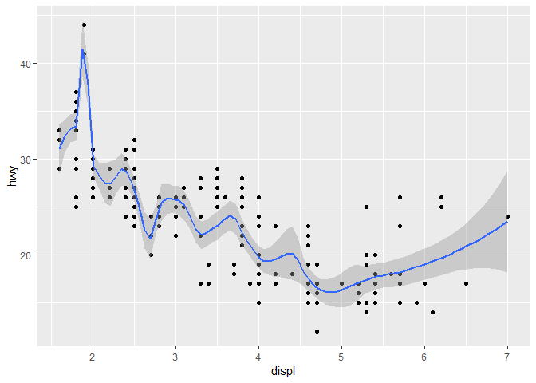

```r
# Figure 6
ggplot(mpg, aes(displ, hwy)) +
  geom_point() +
  geom_smooth(span = 0.2)
```

- `method = "gam"` fits a generalised additive model provided by the **mgcv** package. You need to first load mgcv, then use a formula like `formula = y ~ s(x)` or `y ~ s(x, bs = "cs")` (for large data). This is what `ggplot2` uses when there are more than 1,000 points.

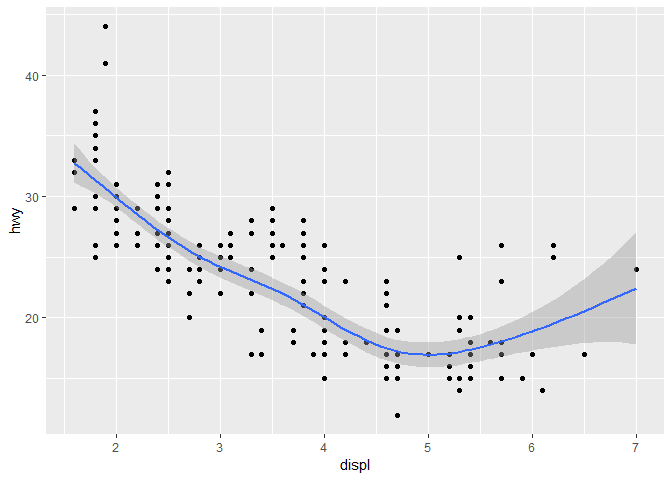

```r
# Figure 7
library(mgcv)
ggplot(mpg, aes(displ, hwy)) +
  geom_point() +
  geom_smooth(method = "gam", formula = y ~ s(x))
```

- `method = "lm"` fits a linear model, giving the line of best fit.

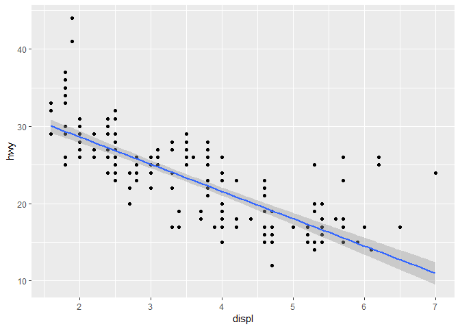

```r
# Figure 8
ggplot(mpg, aes(displ, hwy)) +
  geom_point() +
  geom_smooth(method = "lm")
```

#### 2.2.4.2 Boxplots and Jittered Points

When a set of data includes a categorical variable and one or more continuous variables, you will probably be interested to know how the values of the continuous variables vary with the levels of the categorical variable.

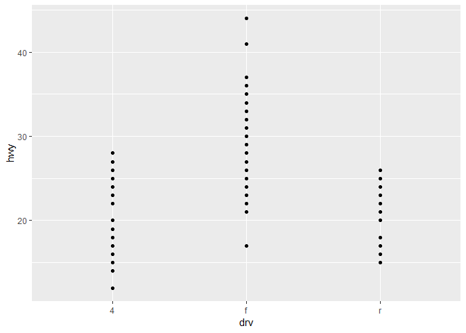

```r
# Figure 9
ggplot(mpg, aes(drv, hwy)) +
  geom_point()
```

- Jittering, `geom_jitter()`, adds a little random noise to the data which can help avoid overplotting.

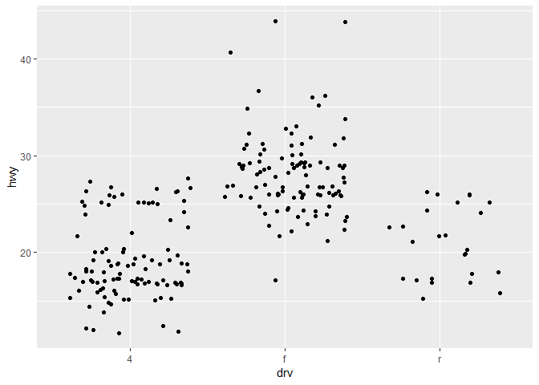

```r
# Figure 10
ggplot(mpg, aes(drv, hwy)) +
  geom_jitter()
```

- Boxplots, `geom_boxplot()`, summarise the shape of the distribution with a handful of summary statistics.

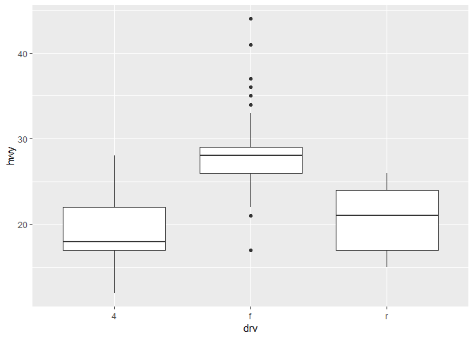

```r
# Figure 11
ggplot(mpg, aes(drv, hwy)) +
  geom_boxplot()
```

- Violin plots, `geom_violin()`, show a compact representation of the density of the distribution, highlighting the areas where more points are found.

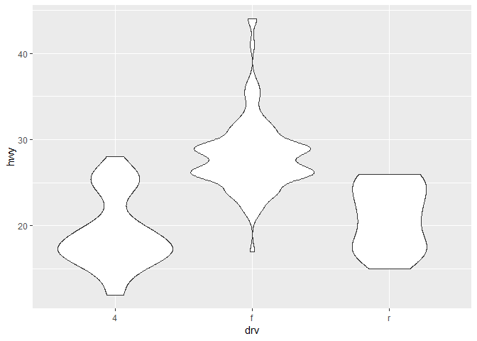

```r
# Figure 12
ggplot(mpg, aes(drv, hwy)) +
  geom_violin()
```

#### 2.2.4.3 Histograms and Frequency Polygons

Histograms and frequency polygons show the distribution of a single numeric variable. They provide more information about the distribution of a single group than boxplots do, at the expense of needing more space.

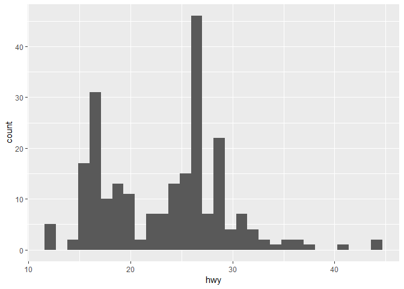

```r
# Figure 13
ggplot(mpg, aes(hwy)) +
  geom_histogram()
```

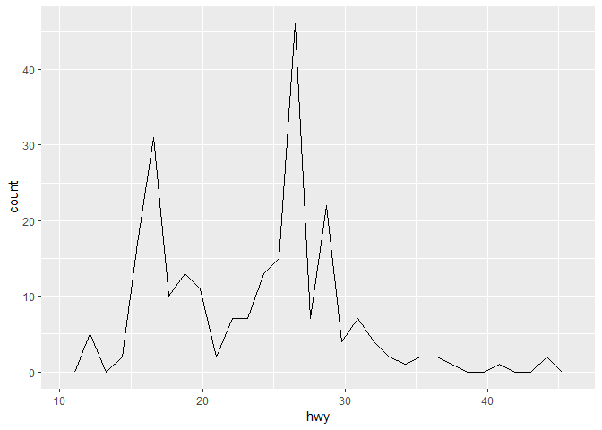

```r
# Figure 14
ggplot(mpg, aes(hwy)) +
  geom_freqpoly()
```

Both of them bin the data, then count the number of observations in each bin. The only difference is the display: histograms use bars and frequency polygons use lines. However, the default just splits your data into 30 bins, which is unlikely to be the best choice.

- Change the width of the bins with the **binwidth** argument:

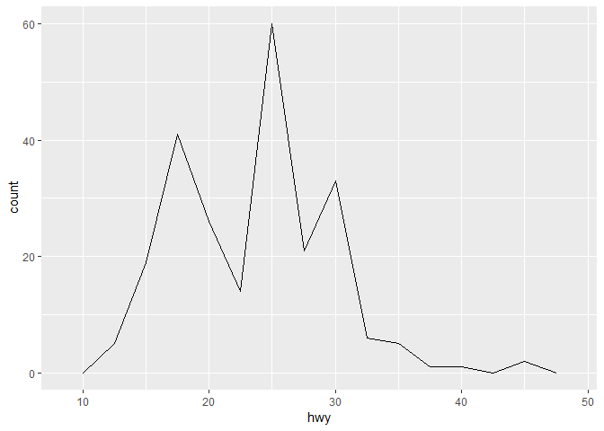

```r
# Figure 15
ggplot(mpg, aes(hwy)) +
  geom_freqpoly(binwidth = 2.5)
```

- Use factting:

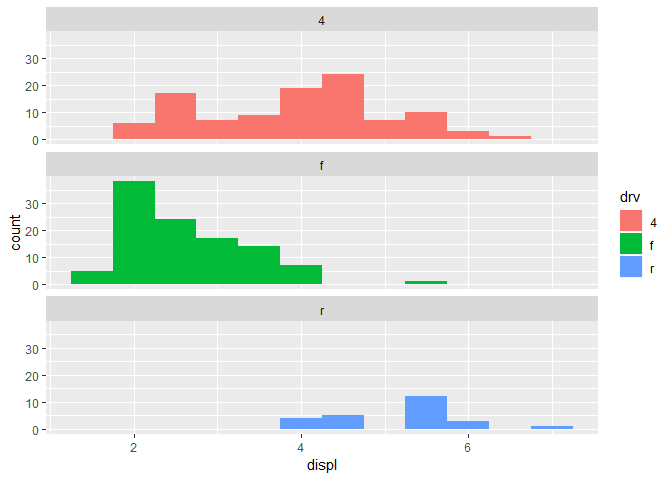

```r
# Figure 16
ggplot(mpg, aes(displ, fill = drv)) +
  geom_histogram(binwidth = 0.5) +
  facet_wrap(~drv, ncol = 1)
```

#### 2.2.4.4 Bar Charts

The discrete analogue of the histogram is the bar chart, `geom_bar()`.

- Plot a bar chart

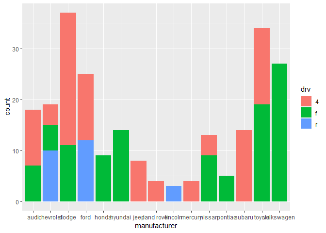

```r
# Figure 17
ggplot(mpg, aes(manufacturer)) +
  geom_bar(aes(fill = drv))
```

#### 2.2.4.5 Time Series with Line and Path Plots

Line and path plots are typically used for time series data. Line plots join the points from left to right, while path plots join them in the order that they appear in the dataset. Line plots usually have time on the x-axis, showing how a single variable has changed over time. Path plots show how two variables have simultaneously changed over time, with time encoded in the way that observations are connected.

We’ll show some time series plots using the **economics** dataset, which contains economic data on the US measured over the last 40 years.

- Show how the unemployment rate change over these years.

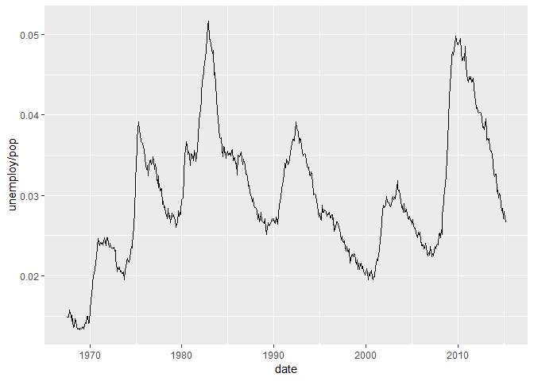

```r
# Figure 18
ggplot(economics, aes(date, unemploy / pop)) +
  geom_line()
```

Now we would like to examine the relationship between unemployment rate and length of unemployment. Meanwhile, we also need to see the evolution over time. The solution is to join points adjacent in time with line segments, forming a path plot.

- Show the relationship between unemployment rate and length of unemployment in each year.

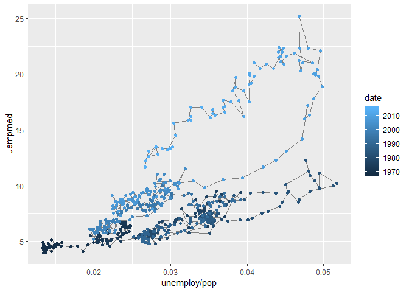

```r
# Figure 19
ggplot(economics, aes(unemploy / pop, uempmed)) +
  geom_path(colour = "grey50") +
  geom_point(aes(colour = date))
```

In the plot, we colour the points to make it easier to see the direction of time. Pay attention to the difference of `geom_point(colour = ...)` and `geom_point(aes(colour = ...))`.

### 2.2.5 Modifying the Axes

Two families of useful helpers let you make the most common modifications. `xlab()` and `ylab()` modify the x- and y-axis labels, while `xlim()` and `ylim()` modify the limits of axes.

- Change the labels and limits of axes:

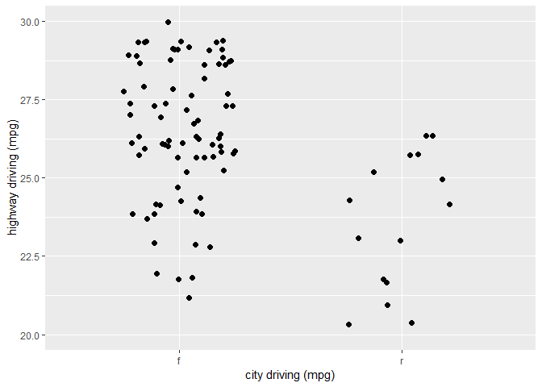

```r
# Figure 20
ggplot(mpg, aes(drv, hwy)) +
  geom_jitter(width = 0.25, size = 2) +
  xlim("f", "r") +
  ylim(20, 30) +
  xlab("city driving (mpg)") +
  ylab("highway driving (mpg)")
```

`xlab(NULL)` and `ylab(NULL)` can remove the axis labels.

### 2.2.6 Output

Most of the time we create a plot object and immediately plot it, but we can also save a plot to a variable and manipulate it:

```r
p <- ggplot(mpg, aes(displ, hwy, colour = factor(cyl))) +
  geom_point()
```

Once we have a plot object, there are a few things we can do with it:

- Render it on screen with `print()`:

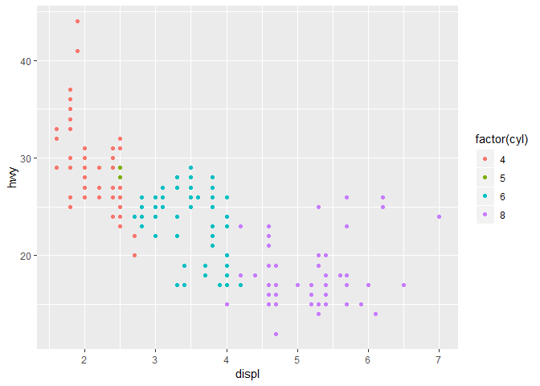

```r
# Figure 21
print(p)
```

- Save it to disk with `ggsave()`:

```
ggsave("plot.png", width = 5, height = 5)
```

- Briefly describe its structure with `summary()`:

```r
summary(p)
```

```
## data: manufacturer, model, displ, year, cyl, trans, drv, cty, hwy,
##   fl, class [234x11]
## mapping:  x = ~displ, y = ~hwy, colour = ~factor(cyl)
## faceting: <ggproto object: Class FacetNull, Facet, gg>
##     compute_layout: function
##     draw_back: function
##     draw_front: function
##     draw_labels: function
##     draw_panels: function
##     finish_data: function
##     init_scales: function
##     map_data: function
##     params: list
##     setup_data: function
##     setup_params: function
##     shrink: TRUE
##     train_scales: function
##     vars: function
##     super:  <ggproto object: Class FacetNull, Facet, gg>
## -----------------------------------
## geom_point: na.rm = FALSE
## stat_identity: na.rm = FALSE
## position_identity
```

- Save a cached copy of it to disk, with `saveRDS()`. This saves a complete copy of the plot object, so you can easily re-create it with `readRDS()`:

```
saveRDS(p, "plot.rds")
q <- readRDS("plot.rds")
```

### 2.2.7 Quick Plots

In some cases, you will want to create a quick plot with a minimum of typing. In these cases you may prefer to use `qplot()` over `ggplot()`. `qplot()` lets you define a plot in a single call, picking a geom by default if you don’t supply one.

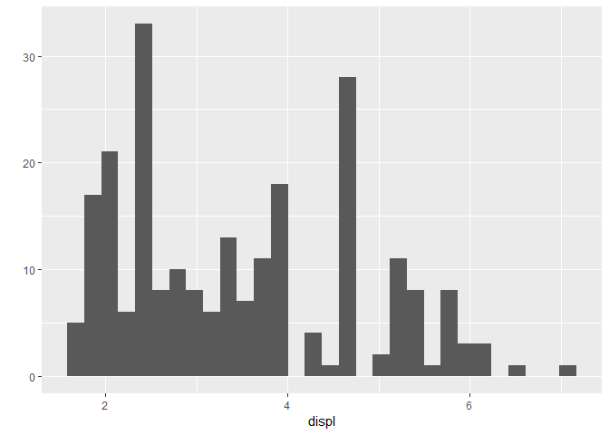

```r
# Figure 22
qplot(displ, data = mpg)
```

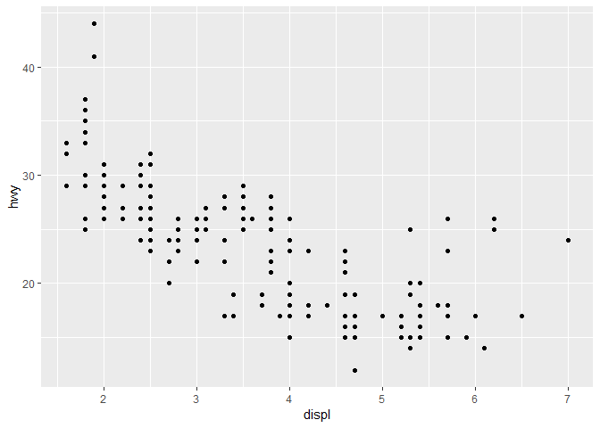

```r
# Figure 23
qplot(displ, hwy, data = mpg)
```

`qplot()` tries to pick a sensible geometry and statistic based on the arguments provided. For example, if you give `qplot()` x and y variables, it’ll create a scatterplot. If you just give it an x, it’ll create a histogram or bar chart depending on the type of variable.

`qplot()` assumes that all variables should be scaled by default. If you want to set an aesthetic to a constant, you need to use `I()`:

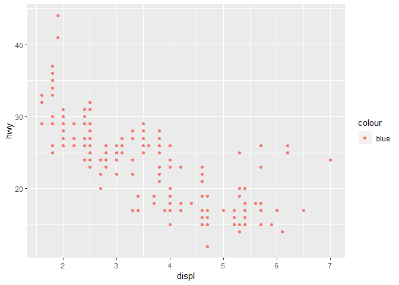

```r
# Figure 24
qplot(displ, hwy, data = mpg, colour = "blue")
```

or

```
ggplot(mpg, aes(displ, hwy)) +
  geom_point(aes(colour = "blue"))
```

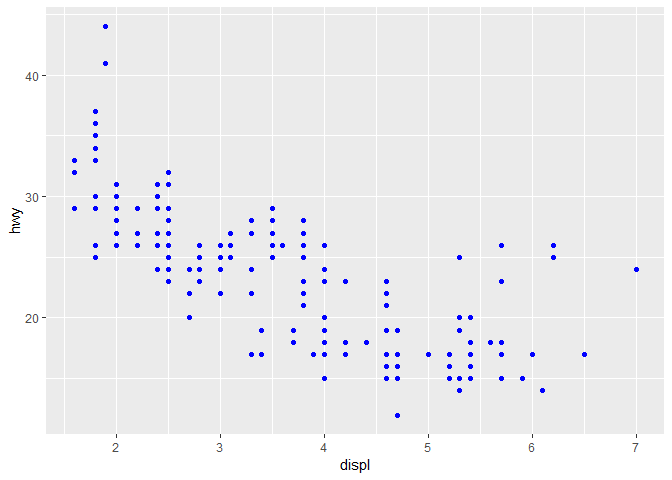

```r
# Figure 25
qplot(displ, hwy, data = mpg, colour = I("blue"))
```

or

```
ggplot(mpg, aes(displ, hwy)) +
  geom_point(colour = "blue")
```

## 2.3 Advanced Learning

This section begins by describing the details in the process of drawing a more complicated plot. I hope they can help you to produce graphics using the same structured thinking that you use to design an analysis, reducing the distance between a plot in your head and one on the page.

### 2.3.1 Labels

`geom_text()` is the main tool to add labels at the specified x and y positions. It has the most aesthetics of any geom, because there are so many ways to control the appearance of a text.

- **family** gives the name of a font: “sans” (the default), “serif”, or “mono”.

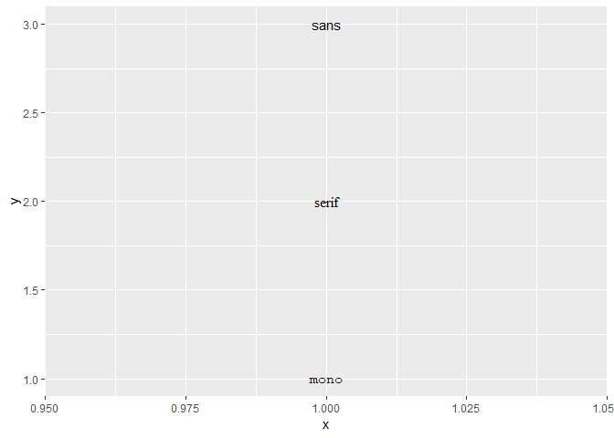

```r
# Figure 26
df <- data.frame(x = 1, y = 3:1, z = c("sans", "serif", "mono"))
ggplot(df, aes(x, y)) +
  geom_text(aes(label = z, family = z))
```

- **fontface** specifies the face: “plain” (the default), “bold” or “italic”.

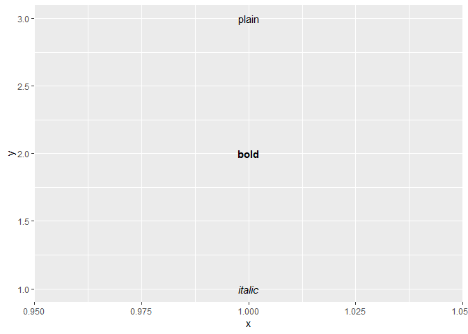

```r
# Figure 27
df <- data.frame(x = 1, y = 3:1, z = c("plain", "bold", "italic"))
ggplot(df, aes(x, y)) +
  geom_text(aes(label = z, fontface = z))
```

- **hjust** (“left”, “center”, “right”, “inward”, “outward”) and **vjust** (“bottom”, “middle”, “top”, “inward”, “outward”) aesthetics can adjust the alignment of the text . The default alignment is centered.

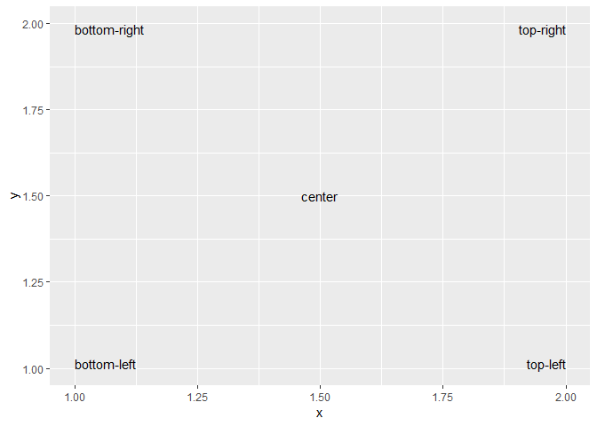

```r
# Figure 28
df <- data.frame(x = c(1, 1, 2, 2, 1.5), y = c(1, 2, 1, 2, 1.5),
                 z = c("bottom-left", "bottom-right","top-left", "top-right", "center"))
ggplot(df, aes(x, y)) +
  geom_text(aes(label = z), vjust = "inward", hjust = "inward")
```

- **size** controls the font size.
- **angle** specifies the rotation of the text in degrees.
- **nudge_x** and **nudge_y** parameters allow you to nudge the text a little horizontally or vertically.

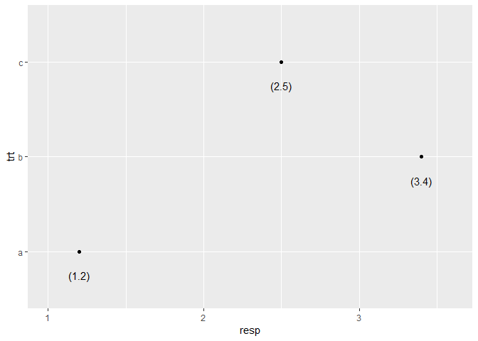

```r
# Figure 29
df <- data.frame(trt = c("a", "b", "c"), resp = c(1.2, 3.4, 2.5))
ggplot(df, aes(resp, trt)) +
  geom_point() +
  geom_text(aes(label = paste0("(", resp, ")")), nudge_y = -0.25) +
  xlim(1, 3.6)
```

- **check_overlap** can overlap labels will be automatically removed.

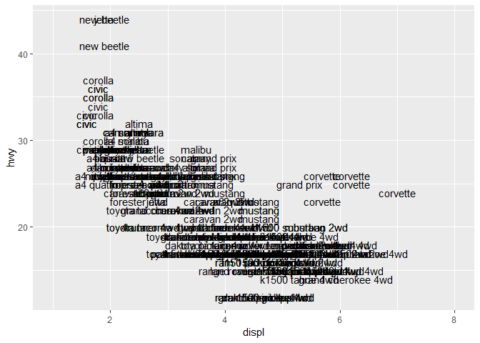

```r
# Figure 30
ggplot(mpg, aes(displ, hwy)) +
  geom_text(aes(label = model)) +
  xlim(1, 8)
```

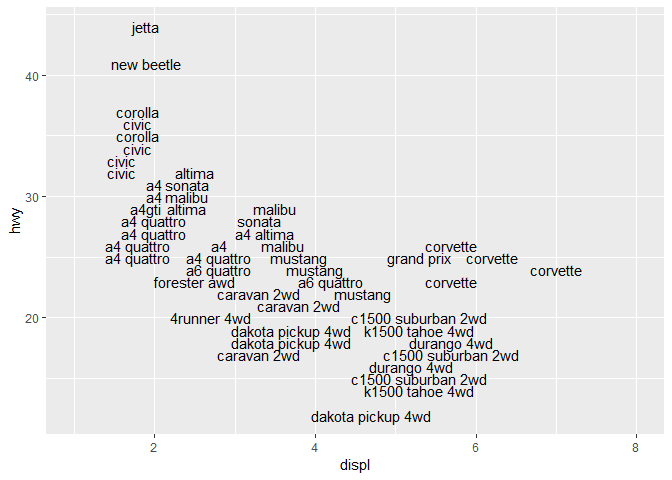

```r
# Figure 31
ggplot(mpg, aes(displ, hwy)) +
  geom_text(aes(label = model), check_overlap = TRUE) +
  xlim(1, 8)
```

- `geom_label()` is a variation on `geom_text()`: it draws a rounded rectangle behind the text.

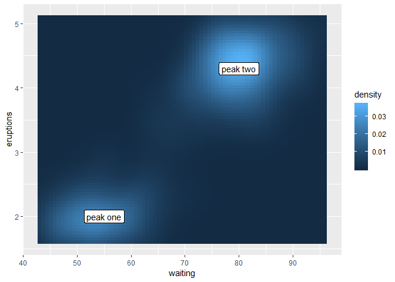

```r
# Figure 32
z <- data.frame(waiting = c(55, 80), eruptions = c(2, 4.3), peak = c("peak one", "peak two"))
ggplot(faithfuld, aes(waiting, eruptions)) +
  geom_tile(aes(fill = density)) +
  geom_label(data = z, aes(label = peak))
```

- a simple example

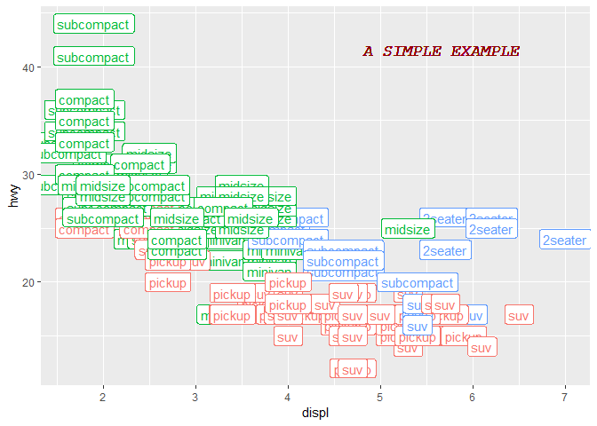

```r
# Figure 33
ggplot(mpg, aes(displ, hwy, colour = drv)) +
  geom_label(aes(label = class), show.legend = FALSE) +
  geom_text(aes(x = 6.5, y = 42, label = "A SIMPLE EXAMPLE"),
            vjust = "inward", hjust = "inward",
            fontface = "italic",
            family = "mono",
            size = 5,
            colour = "darkred")
```

### 2.3.2 Annotations

Annotations add metadata to our plot. But metadata is just data, so we can use:

- `geom_rect()` to highlight interesting rectangular regions of the plot. `geom_rect()` has aesthetics `xmin`, `xmax`, `ymin` and `ymax`.

```r
head(presidential)
```

| name | start | end | party |
| --- | --- | --- | --- |
| Eisenhower | 1953-01-20 | 1961-01-20 | Republican |
| Kennedy | 1961-01-20 | 1963-11-22 | Democratic |
| Johnson | 1963-11-22 | 1969-01-20 | Democratic |
| Nixon | 1969-01-20 | 1974-08-09 | Republican |
| Ford | 1974-08-09 | 1977-01-20 | Republican |
| Carter | 1977-01-20 | 1981-01-20 | Democratic |

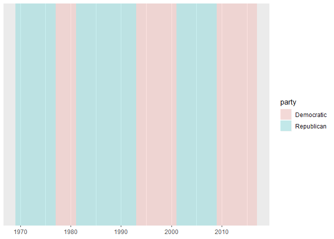

```r
presidential <- subset(presidential, start > economics$date[1])
# Figure 34
p <- ggplot(economics) +
  geom_rect(aes(xmin = start, xmax = end, fill = party),
            ymin = -Inf, ymax = Inf, alpha = 0.2,
            data = presidential)
print(p)
```

We annotate this plot with which president was in power at the time. There is one special thing to note: the use of `-Inf` and `Inf` as positions. These refer to the top and bottom (or left and right) limits of the plot.

- `geom_line()`, `geom_path()` and `geom_segment()` to add lines.

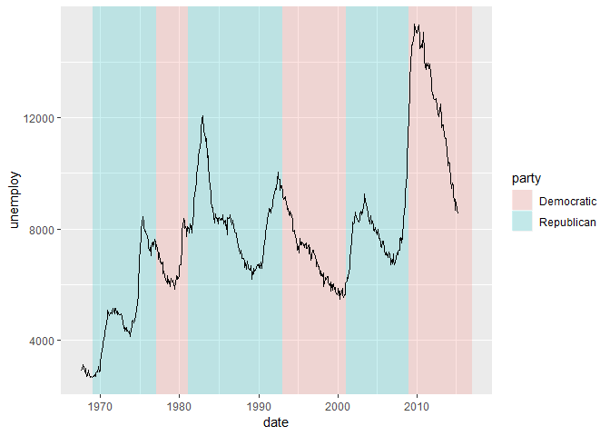

```r
# Figure 35
p <- p + geom_line(aes(date, unemploy))
print(p)
```

- `geom_vline()`, `geom_hline()` and `geom_abline()` allow you to add reference lines (sometimes called rules), that span the full range of the plot.

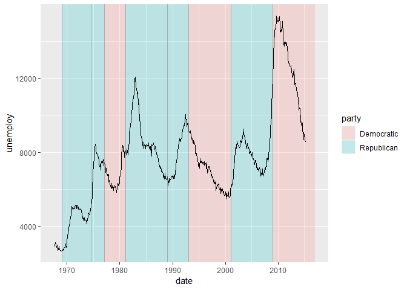

```r
# Figure 36
p <- p + geom_vline(aes(xintercept = as.numeric(start)),
                    data = presidential,
                    colour = "grey50",
                    alpha = 0.5)
print(p)
```

- `geom_text()` to add text descriptions or to label points. Most plots will not benefit from adding text to every single observation on the plot, but labelling outliers and other important points is very useful.

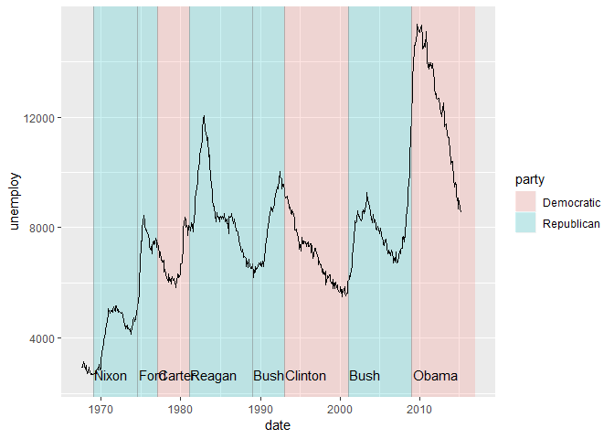

```r
# Figure 37
p <- p + geom_text(aes(x = start, y = 2500, label = name),
                   data = presidential,
                   size = 4,
                   vjust = 0, hjust = 0,
                   nudge_x = 50)
print(p)
```

- We can use `annotate()` to add a single annotation to a plot

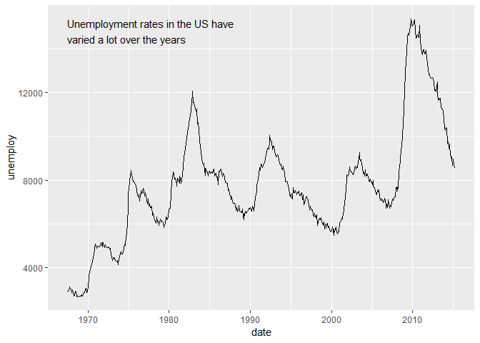

```r
# Figure 38
yrng <- range(economics$unemploy)
xrng <- range(economics$date)
caption <- paste(strwrap("Unemployment rates in the US have varied a lot over the years", 40),
                 collapse = "\n")
ggplot(economics, aes(date, unemploy)) +
  geom_line() +
  annotate("text", x = xrng[1], y = yrng[2],
           label = caption,
           hjust = 0, vjust = 1,
           size = 4)
```

- `geom_abline()` is useful when comparing groups across facets. In the following plot, it’s much easier to see the subtle differences if we add a reference line.

```r
head(diamonds)
```

| carat | cut | color | clarity | depth | table | price | x | y | z |
| --- | --- | --- | --- | --- | --- | --- | --- | --- | --- |
| 0.23 | Ideal | E | SI2 | 61.5 | 55 | 326 | 3.95 | 3.98 | 2.43 |
| 0.21 | Premium | E | SI1 | 59.8 | 61 | 326 | 3.89 | 3.84 | 2.31 |
| 0.23 | Good | E | VS1 | 56.9 | 65 | 327 | 4.05 | 4.07 | 2.31 |
| 0.29 | Premium | I | VS2 | 62.4 | 58 | 334 | 4.20 | 4.23 | 2.63 |
| 0.31 | Good | J | SI2 | 63.3 | 58 | 335 | 4.34 | 4.35 | 2.75 |
| 0.24 | Very Good | J | VVS2 | 62.8 | 57 | 336 | 3.94 | 3.96 | 2.48 |

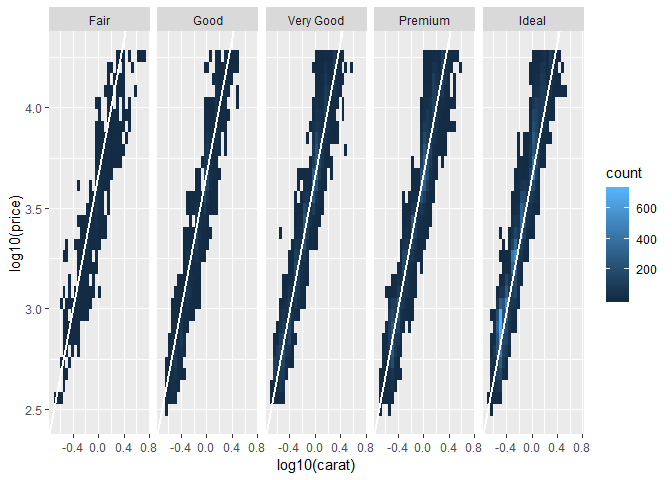

```r
# Figure 39
mod_coef <- coef(lm(log10(price) ~ log10(carat), data = diamonds))
ggplot(diamonds, aes(log10(carat), log10(price))) +
  geom_bin2d() +
  geom_abline(intercept = mod_coef[1], slope = mod_coef[2],
              colour = "white", size = 1) +
  facet_wrap(~cut, nrow = 1)
```

`geom_bin2d()` divides the plane into rectangles, counts the number of cases in each rectangle, and then (by default) maps the number of cases to the rectangle’s fill.

### 2.3.3 Scales

Scales control the mapping from data to aesthetics. They take your data and turn it into something that you can see, like size, colour, position or shape. Scales also provide the tools that let you read the plot: the **axes** and **legends**. Formally, each scale is a function from a region in data space (the domain of the scale) to a region in aesthetic space (the range of the scale). The axis or legend is the inverse function: it allows you to convert visual properties back to data.

A scale is required for every aesthetic used on the plot. When you write:

```
ggplot(mpg, aes(displ, hwy)) +
  geom_point(aes(colour = class))
```

What actually happens is this:

```
ggplot(mpg, aes(displ, hwy)) +
  geom_point(aes(colour = class)) +
  scale_x_continuous() +
  scale_y_continuous() +
  scale_colour_discrete()
```

It would be tedious to manually add a scale every time you used a new aesthetic, so *ggplot2* does it for you. But if we want to override the defaults, we’ll need to add the scale yourself, like this:

```
ggplot(mpg, aes(displ, hwy)) +
  geom_point(aes(colour = class)) +
  scale_x_continuous("A really awesome x axis label") +
  scale_y_continuous("An amazingly great y axis label")
```

When we `+` a scale, we’re not actually adding it to the plot, but overriding the existing scale. This means that the following two specifications are equivalent:

```
ggplot(mpg, aes(displ, hwy)) +
  geom_point() +
  scale_x_continuous("Label 1") +
  scale_x_continuous("Label 2")
```

```
ggplot(mpg, aes(displ, hwy)) +
  geom_point() +
  scale_x_continuous("Label 2")
```

You’ve probably already figured out the naming scheme for scales:

| Scale | The name of the aesthetic | The name of the scale |
| --- | --- | --- |
| scale | colour | continuous |
|  | shape | discrete |
|  | x | brewer |
|  | y |  |

### 2.3.4 Axes

The component of a scale that you’re most likely to want to modify is the guide, the axis or legend associated with the scale. There are many natural correspondences between the two

| Axis | Legend | Argument name |
| --- | --- | --- |
| Label | Title | name |
| Ticks & grid line | Key | breaks |
| Tick label | Key label | labels |

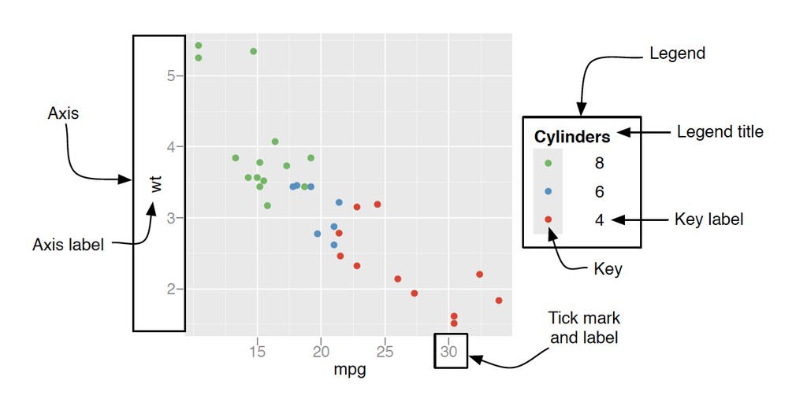

#### 2.3.4.1 Name

The first argument to the scale function, name, is the axes/legend title. You can supply text strings (using `\n` for line breaks) or mathematical expressions in `quote()`

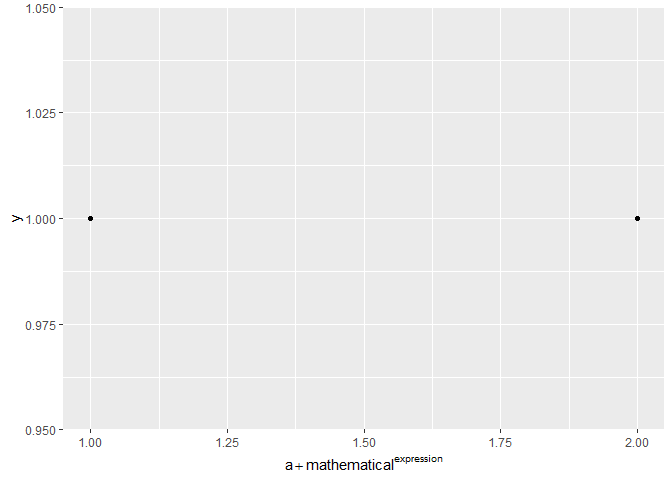

```r
# Figure 40
df <- data.frame(x = 1:2, y = 1, z = "a")
ggplot(df, aes(x, y)) +
  geom_point() +
  scale_x_continuous(quote(a + mathematical ^ expression))
```

Because tweaking these labels is such a common task, there are three helpers that save you some typing:`xlab()`, `ylab()` and `labs()`:

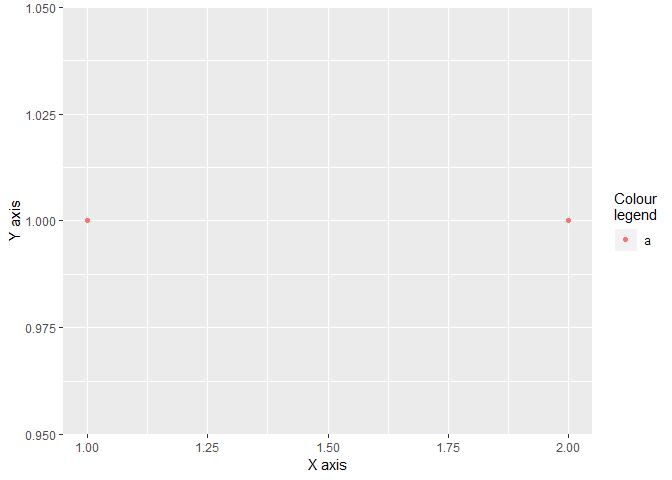

```r
# Figure 41
ggplot(df, aes(x, y)) + geom_point(aes(colour = z)) +
  labs(x = "X axis", y = "Y axis", colour = "Colour\nlegend")
```

There are two ways to remove the axis label.

1. `labs(x = "", y = "")` : omits the label, but still allocates space;
2. `labs(x = NULL, y = NULL)`: removes the label and its space.

#### 2.3.4.2 Breaks and Labels

The breaks argument controls which values appear as tick marks on axes and keys on legends. Each break has an associated label, controlled by the labels argument. If you set labels, you must also set breaks; otherwise, if data changes, the breaks will no longer align with the labels.

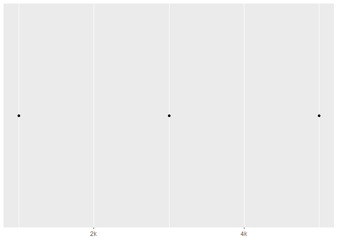

```r
# Figure 42
df <- data.frame(x = c(1, 3, 5) * 1000, y = 0.5)
ggplot(df, aes(x, y)) +
  geom_point() +
  labs(x = NULL, y = NULL) +
  scale_x_continuous(breaks = c(2000, 4000), labels = c("2k", "4k")) +
  scale_y_continuous(breaks = c(0.25, 0.75), labels = c("25%", "75%"))
```

The scales package provides a number of useful labelling functions:

1. `scales::comma_format()` adds commas to make it easier to read large numbers.
2. `scales::unit_format(unit, scale)` adds a unit suffix, optionally scaling.
3. `scales::dollar_format(prefix, suffix)` displays currency values, rounding to two decimal places and adding a `prefix` or `suffix`.
4. `scales::wrap_format()` wraps long labels into multiple lines.

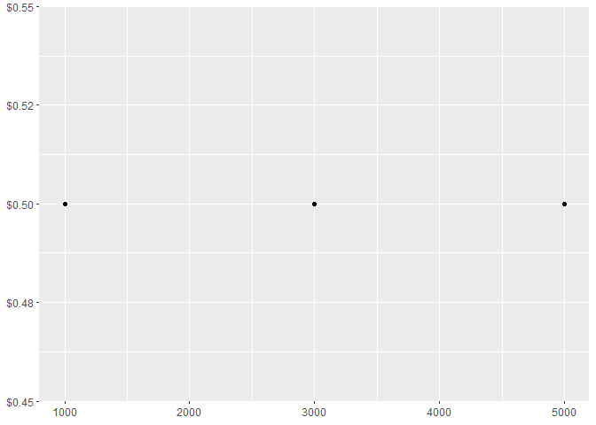

```r
# Figure 43
df <- data.frame(x = c(1, 3, 5) * 1000, y = 0.5)
ggplot(df, aes(x, y)) +  geom_point() +  labs(x = NULL, y = NULL) +
  scale_y_continuous(labels = scales:::dollar_format(prefix="$"))
```

You can adjust the minor breaks (the faint grid lines that appear between the major grid lines) by supplying a numeric vector of positions to the `minor_breaks` argument. This is particularly useful for log scales:

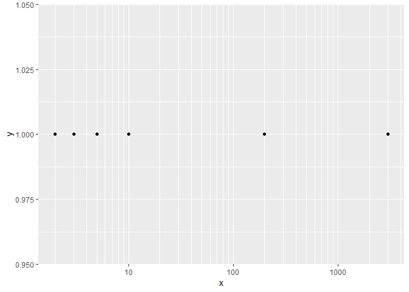

```r
# Figure 44
df <- data.frame(x = c(2, 3, 5, 10, 200, 3000), y = 1)
mb <- as.numeric(1:10 %o% 10 ^ (0:4))
ggplot(df, aes(x, y)) +
  geom_point() +
  scale_x_log10(minor_breaks = mb)
```

### 2.3.5 Legends

A legend may need to draw symbols from multiple layers. For example, if you’ve mapped colour to both points and lines, the keys will show both points and lines.

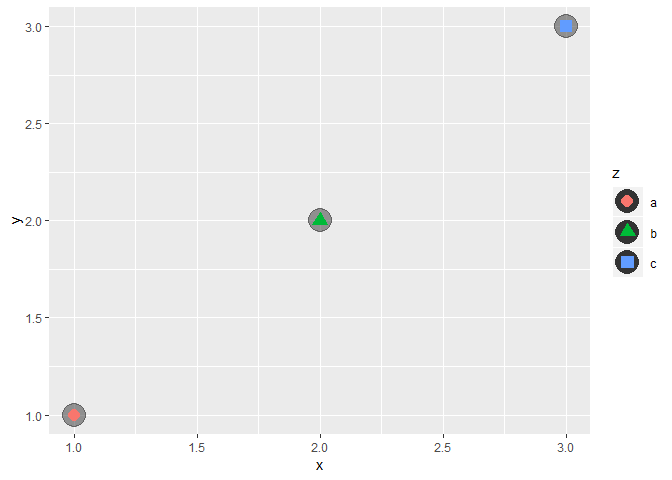

```r
# Figure 45
df <- data.frame(x = 1:3, y = 1:3, z = c("a", "b", "c"))
ggplot(df, aes(x, y)) +
  geom_point(size = 8, colour = "grey20", alpha = 0.5, show.legend = TRUE) +
  geom_point(aes(colour = z, shape = z), size = 4) +
  guides(colour = guide_legend(override.aes = list(alpha = 1))) +
  guides(fill = guide_legend(reverse=TRUE))
```

As we can see, if we want the geoms in the legend to display differently to the geoms in the plot. This is particularly useful when you’ve used transparency or size to deal with moderate overplotting and also used colour in the plot. You can do this using the **override.aes** parameter of `guide_legend()`.

A number of settings that affect the overall display of the legends are controlled through the theme system. You can modify theme settings with the `theme()` function.

The position and justification of legends are controlled by the theme setting legend.position, which takes values “right”, “left”, “top”, “bottom”, or “none” (no legend).

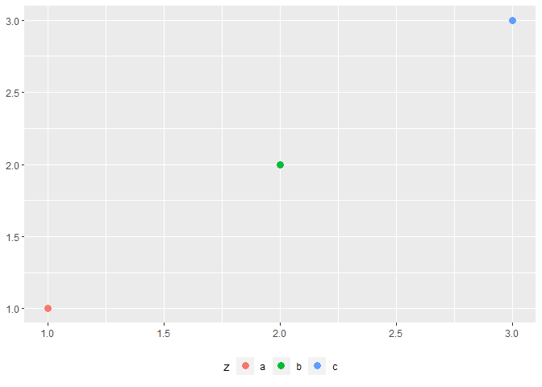

```r
# Figure 46
df <- data.frame(x = 1:3, y = 1:3, z = c("a", "b", "c"))
ggplot(df, aes(x, y)) +
  geom_point(aes(colour = z), size = 3) +
  xlab(NULL) +
  ylab(NULL) +
  theme(legend.position = "bottom")
```

Alternatively, if there’s a lot of blank space in your plot you might want to place the legend inside the plot. You can do this by setting `legend.position` to a numeric vector of length two. The numbers represent a relative location in the panel area: `c(0, 1)` is the top-left corner and `c(1, 0)` is the bottom-right corner. You control which corner of the legend the `legend.position` refers to with `legend.justification`, which is specified in a similar way.

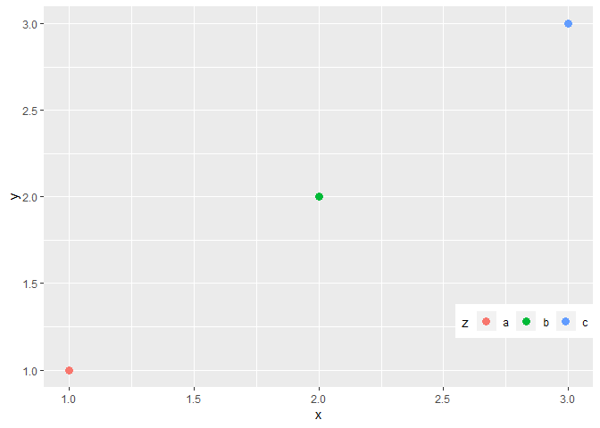

```r
# Figure 47
ggplot(df, aes(x, y)) +
  geom_point(aes(colour = z), size = 3) +
  theme(legend.position = c(0.8, 0.2), legend.justification = c(0.2, 0.8),
        legend.direction = "horizontal")
```

- A simple example

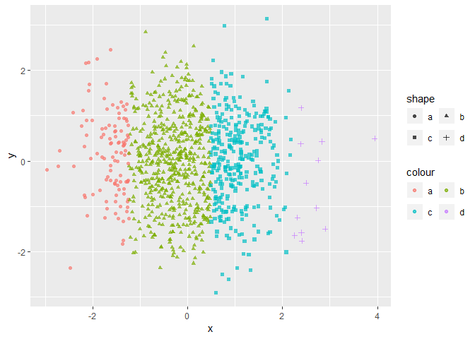

```r
# Figure 48
df <- data.frame(x = rnorm(1000), y = rnorm(1000))
df$z <- cut(df$x, 4, labels = c("a", "b", "c", "d"))
ggplot(df, aes(x, y)) +
  geom_point(aes(colour = z, shape = z), alpha = 0.7) +
  guides(colour = guide_legend(ncol = 2, byrow = TRUE, alpha = 1)) +
  guides(shape = guide_legend(ncol = 2, byrow = TRUE, alpha = 1)) +
  scale_colour_discrete("colour") +
  scale_shape_discrete("shape")
```

### 2.3.6 Date

Date and date/time data are continuous variables with special labels. ggplot2 works with **Date** (for dates) and **POSIXct** (for date/times) classes: if your dates are in a different format you will need to convert them with `as.Date()` or `as.POSIXct()`. `scale_x_date()` and `scale_x_datetime()` work similarly to `scale_x_continuous()` but have special date_breaks and date_labels arguments that work in date-friendly units:

- `date_breaks()` and `date_minor_breaks()` allows you to position breaks by date units (years, months, weeks, days, hours, minutes, and seconds). For example, `date_breaks = "2 weeks"` will place a major tick mark every two weeks.
- `date_labels()` controls the display of the labels using the same formatting strings as in `strptime()` and format():

| String | Meaning |
| --- | --- |
| %S | second (00-59) |
| %M | minute (00-59) |
| %l | hour, in 12-hour clock (1-12) |
| %I | hour, in 12-hour clock (01-12) |
| %p | am/pm |
| %H | hour, in 24-hour clock (00-23) |
| %a | day of week, abbreviated (Mon-Sun) |
| %A | day of week, full (Monday-Sunday) |
| %e | day of month (1-31) |
| %d | day of month (01-31) |
| %m | month, numeric (01-12) |
| %b | month, abbreviated (Jan-Dec) |
| %B | month, full (January-December) |
| %y | year, without century (00-99) |
| %Y | year, with century (0000-9999) |

For example, if you wanted to display dates like 14/10/1979, you would use the string “%d/%m/%Y”.

```r
head(economics)
```

| date | pce | pop | psavert | uempmed | unemploy |
| --- | --- | --- | --- | --- | --- |
| 1967-07-01 | 507.4 | 198712 | 12.5 | 4.5 | 2944 |
| 1967-08-01 | 510.5 | 198911 | 12.5 | 4.7 | 2945 |
| 1967-09-01 | 516.3 | 199113 | 11.7 | 4.6 | 2958 |
| 1967-10-01 | 512.9 | 199311 | 12.5 | 4.9 | 3143 |
| 1967-11-01 | 518.1 | 199498 | 12.5 | 4.7 | 3066 |
| 1967-12-01 | 525.8 | 199657 | 12.1 | 4.8 | 3018 |

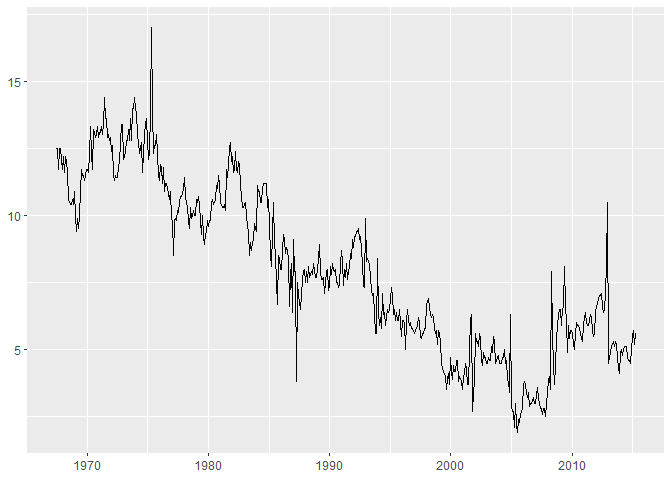

```r
base <- ggplot(economics, aes(date, psavert)) +
  geom_line(na.rm = TRUE) +
  labs(x = NULL, y = NULL)
# Figure 49
print(base)
```

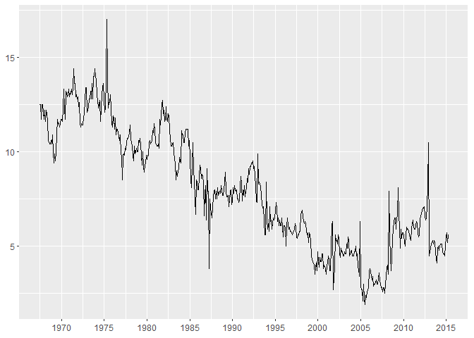

```r
# Figure 50
base + scale_x_date(date_labels = "%Y", date_breaks = "5 years")
```

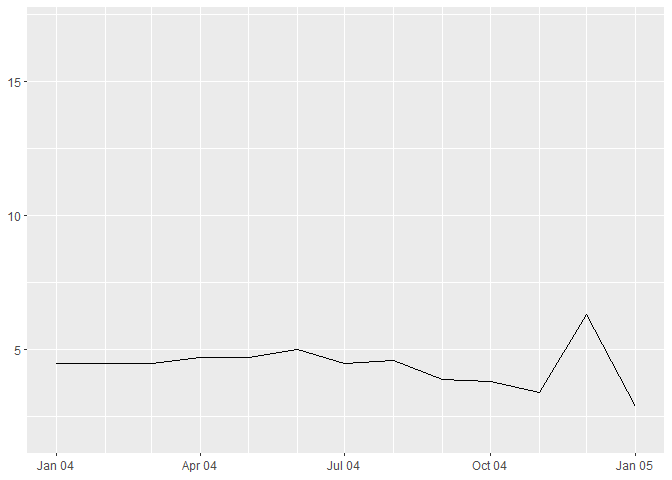

```r
# Figure 51
base + scale_x_date(limits = as.Date(c("2004-01-01", "2005-01-01")),
                    date_labels = "%b %y",
                    date_minor_breaks = "1 month")
```

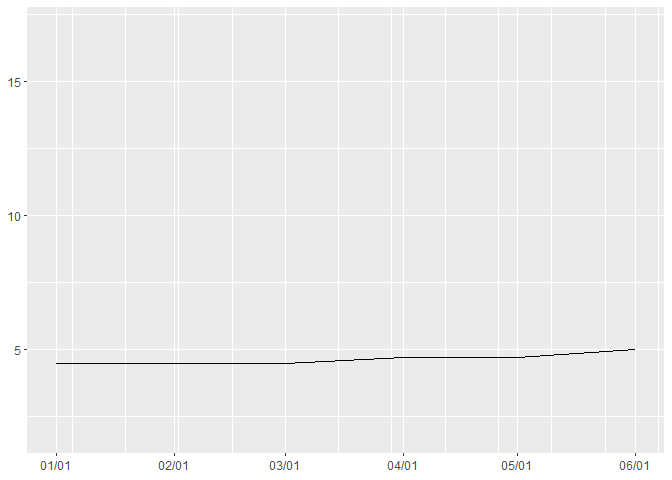

```r
# Figure 52
base + scale_x_date(limits = as.Date(c("2004-01-01", "2004-06-01")),
                    date_labels = "%m/%d",
                    date_minor_breaks = "2 weeks")
```